# Data Analysis Competition

Topic: Data Management and Data Summarization

**(with R, R Markdown)**

## Libraries

```r
library(scales)
library(tidyverse)
library(haven)
library(kableExtra)
```

## Data

Let’s use the given dataset (from Bangladesh Demographic and Health Survey, 2017-18). The respondents were women of reproductive age (15–49 years) who had one or more live birth in the five years preceding the survey.

```r
setwd("C:/Users/has9a/R")
bdhs_data <- read_sav("Data_Competition_level-I.sav")
```

Now take a glimpse of our data by `glimpse(bdhs_data)`. We see some of the variables are `haven_labelled`. We can convert these labelled variables into factors. Converting to factors is important for modelling and/or plotting. We will do this by `as_factor()` function while solving questions. Also, we will check labels of any variable by `attributes()` function. It helps us to analyze data as well as to find out predefined value for missing values, `NA`.

## Discussion

### #Q1

###### Required Variables:

- `CASEID` (Case Identification)
- `V025` (Type of place of residence)
- `V106` (Highest educational level)
- `V157` (Frequency of reading newspaper or magazine)
- `V158` (Frequency of listening to radio)
- `V159` (Frequency of watching television)
- `M14` (Number of antenatal visits during pregnancy)
- `M17` (Delivery by caesarean section)

###### Steps:

**1.** Selecting required variables for this question and assigning them to `q1_data`.

```r
q1_data <- bdhs_data %>% select(1,8,9,10,11,12,23,24)
```

**2.** Observing data by `CASEID`. And checking whether the responses on variables (`CASEID`, `V157`, `V158`, `V159`), prerequisites, are same or not for every distinct respondent.

```r
nrow(distinct(q1_data, CASEID, V157, V158, V159, .keep_all = T)) == nrow(distinct(bdhs_data %>% select(1)))
## [1] TRUE
```

**3.** As it’s `TRUE`, we can work with this filtered dataframe (7562 variables).

```r
q1_data <- distinct(q1_data, CASEID, V157, V158, V159, .keep_all = T)
```

**4.** Now creating new variable `media_exposure`.

```r
q1_data <- q1_data %>%
  mutate(media_exposure = if_else(
    (V157 == 2 | V158 == 2 | V159 == 2 |
       V157 == 3 | V158 == 3 | V159 == 3),
    1, 2))

q1_data$media_exposure <- q1_data$media_exposure %>%
  labelled(c("Exposed"=1, "Not Exposed"=2),
           label="Media Exposure")


q1_data = q1_data %>%
  mutate(media_exposure = as_factor(media_exposure))
```

**5.** Visualizing `media_exposure`.

```r
kable(q1_data %>%
  group_by(media_exposure) %>%
  summarise(n = n()) %>%
  mutate(rel.freq = paste0(round(100 * n/sum(n), 1), "%")),
  col.names = c("Media Exposure", "Frequency", "Percentage"))
```

| Media Exposure | Frequency | Percentage |
| --- | --- | --- |
| Exposed | 4166 | 55.1% |
| Not Exposed | 3396 | 44.9% |

###### Discussing Behavior Of Respondents:

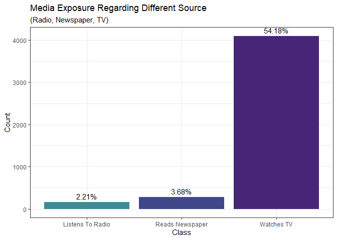

*Code for this graph is available [🔗 here](https://raw.githubusercontent.com/has9alv3/Data-Management/main/Graphs/Q1.%20Media%20Exposure%20Regarding%20Different%20Source.R)*

It is evident from our analysis that a large number of respondents (44.9%) are not exposed to media. 54.18% of the respondents reported watching television. 3.68% reported reading newspapers or magazines, and 2.21% reported listening to the radio.

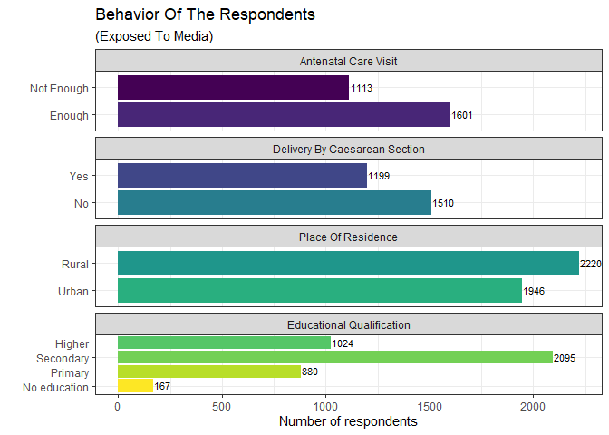

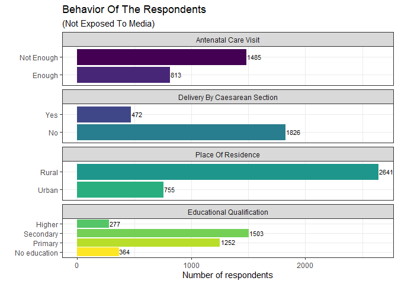

*Code for this graph is available [🔗 here](https://raw.githubusercontent.com/has9alv3/Data-Management/main/Graphs/Q1.%20Behavior%20Of%20The%20Respondents.R)*

We have analyzed other provided variables to see if those have any relation with the behavior of our respondents regarding media exposure. And they do have. Respondents exposed to media are seen to have taken better decisions regarding antenatal care visits. We also find that respondents living in rural areas are less exposed to media. And respondents not exposed to media have relatively lower educational qualifications. We cannot say media exposure affected these variables, but we can say that media exposure does have a relation with these variables.

### #Q2

###### Required Variables:

- `CASEID` (Case Identification)
- `V191` (Wealth index factor score)

###### Steps:

**1.** Selecting required variables for this question and assigning them to `q2_data`.

```r
q2_data <- bdhs_data %>% select(1,15)
```

**2.** Observing data by `CASEID`. And checking whether the responses on `V191` (wealth index factor score) are same or not for every distinct respondent.

```r
nrow(distinct(q2_data)) == nrow(distinct(bdhs_data %>% select(1)))
## [1] TRUE
```

**3.** As it’s `TRUE`, we can work with this filtered dataframe (7562 variables).

```r
q2_data <- distinct(q2_data)
sum(is.na(q2_data))  # No Missing Values
## [1] 0
```

**4.** Now creating new variable `economic_status` by using the ‘wealth index factor score’ in a proper way that divide the ranked ‘wealth index factor score’ scores in to three equal quantiles (e.g., 33.33 percentile each) with categories: poor, middle and rich.

```r
q2_data <- bdhs_data %>% select(1,15)
rank_q2 <- rank(q2_data$V191, ties.method = "min")
rank_q2 <- ntile(rank_q2, 3)

q2_data <- q2_data%>%
  mutate(economic_status = rank_q2)

q2_data$economic_status <- labelled(q2_data$economic_status,
                              c("Poor"=1, "Middle"=2, "Rich"=3),
                              label="Economic Status")

q2_data <- q2_data %>%
  mutate(economic_status = as_factor(economic_status))
```

**5.** Visualizing `economic_status`.

```r
kable(q2_data %>%
  group_by(economic_status) %>%
  summarise(n = n()) %>%
  mutate(rel.freq = paste0(round(100 * n/sum(n), 2), "%")),
  col.names = c("Economic Status", "Frequency", "Percentage"))
```

| Economic Status | Frequency | Percentage |
| --- | --- | --- |
| Poor | 2920 | 33.34% |
| Middle | 2920 | 33.34% |
| Rich | 2919 | 33.33% |

**6.** Let’s see the graphical representation of `economic_status`

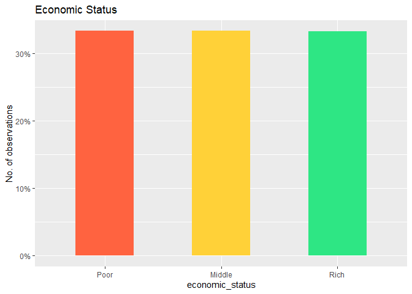

```r
ggplot(q2_data, aes(economic_status,
                    y = (..count..)/sum(..count..),
                    fill = economic_status)) +
  geom_bar(width=0.5) +
  labs(title = "Economic Status",
       x = "economic_status",
       y = "No. of observations") +
  scale_fill_manual(values=c('#ff6340', '#ffd138', '#2ee684')) +
  theme(legend.position="none") +
  scale_y_continuous(labels = function(x) paste0(x*100, "%"))
```

###### Describing The Variable `economic_status`:

The variable `economic_status` follows a discrete uniform distribution with parameters a, b, and n [a,b integers with b ≥ a and n = b – a + 1]. Here, a = 1, b = 3, and n = 3.

The PMF of a uniform distribution is 1/n. For n = 3, the PMF of `economic_status` should be 1/3.

We find this `TRUE` because the three categories poor, middle, and rich all have a relative frequency of 33.33%. Both the mean and the median of `economic_status` are (a+b)/2 = 2, the middle category. From this information, we can also say that the skewness of `economic_status` is zero. The skewness is zero for all discrete uniform distributions.

###### Additional Notes:

Quantiles divide the data into segments consisting of an equal number of observations. So it is reasonable to have 33.33% observations each for poor, middle, and rich. However, quantiles do not distribute the range of the data evenly. So these three categories do not have their Wealth Index Factor Score evenly distributed. We get a clear picture of this from box plots. The box plots show the range of each category along with other measures.

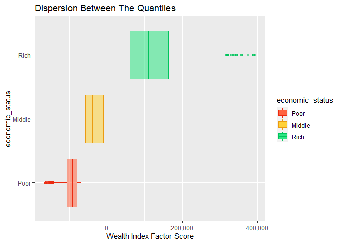

*Code for this graph is available [🔗 here](https://raw.githubusercontent.com/has9alv3/Data-Management/main/Graphs/Q2.%20Dispersion%20Between%20The%20Quantiles.R)*

### #Q3

###### Required Variables:

- `CASEID` (Case Identification)
- `BORD` (Birth order number)
- `B11` (Preceding birth interval in months)

###### Steps:

**1.** Selecting required variables for this question and assigning them to `q3_data`.

```r
q3_data <- bdhs_data %>% select(1,17,22)
```

**2.** Filtering `q3_data` by removing first birth and its twins. Adding `NA` where preceding birth interval, `B11`, equals to 999.

```r
q3_data <- q3_data %>% filter(BORD != 1 & B11 != 0)
q3_data[q3_data==999] <- NA
```

**3.** As the preceding birth interval data is quantitative, suitable measure of central tendency is either `mean` or `median`.

```r
summary(q3_data$B11)
```

```
##    Min. 1st Qu.  Median    Mean 3rd Qu.    Max.    NA's
##    7.00   35.00   54.00   60.28   80.00  196.00      28
```

**4.** Density curve with histogram will help us to to choose better measure of central tendency within `mean` and `median.`

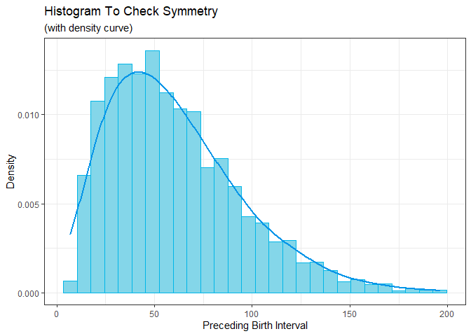

```r
q3_data %>% drop_na(B11) %>%
  ggplot(aes(x = as.numeric(B11))) +
  geom_histogram(aes(y = ..density..),
                 binwidth = 7,
                 fill = "#84d6e9",
                 color = "#00b6e8") +
  geom_density(adjust=2,
               color = "#0294e8",
               lwd=1)+
  labs(title = "Histogram To Check Symmetry",
       subtitle = "(with density curve)",
       x = "Preceding Birth Interval",
       y = "Density") +
  theme_bw()
```

**5.** As it does not seem symmetric, suitable measure of central tendency is `median`.

```r
median(q3_data$B11,na.rm = T)
## [1] 54
```

###### Interpretation:

For ‘preceding birth interval’, the median is 54 months (4.5 years). That informs us women tend to give birth at a 4.5 years interval.

The median is a suitable measure of central tendency for skewed distributions. Extreme values affect the median less than they affect the mean. Also, we can’t be sure if the extreme values are outliers or not. For example, the minimum value in ‘preceding birth interval’ is seven months. Guinness World Records says the shortest birth interval (not including twins) in the world is around seven months. So there is a high possibility that this is an outlier. The maximum of our data is more than sixteen years, which does not represent our data at all. Extreme values like this can highly affect the mean. Therefore, the median is a better choice.

### #Q4

###### Required Variables:

- `CASEID` (Case Identification)
- `V008` (Date of interview (CMC))
- `B3` (Date of birth (CMC))
- `B5` (Child is alive)
- `B7` (Age at death in months)

###### Steps:

**1.** Selecting required variables for this question and assigning them to `q4_data`.

```r
q4_data <- bdhs_data %>% select(1,5,18,19,21)
```

**2.** Creating a quantitative variable `age_of_child`. The variable takes value equal to ‘current age’=`V008-B3` of the children who are alive. Alternatively, it takes value equal to ‘age at death’=`B7` for those children who had died before the interview date.

```r
q4_data <- q4_data %>%
  mutate(age_of_child = if_else(
    (B5==1),
    V008-B3, B7))
```

**3.** Creating a dichotomous variable `survival_status` which takes value `Survived` if the child is alive and `Died` if the child is not alive.

```r
q4_data <- q4_data %>%
  mutate(survival_status = if_else(
    (B5==1),
    "Survived", "Died"))
```

**4.** Let’s check the histogram of `age_of_child` (as it’s a quantitative variable, either `mean` or `median` is better measure of central tendency) for the children who are not alive.

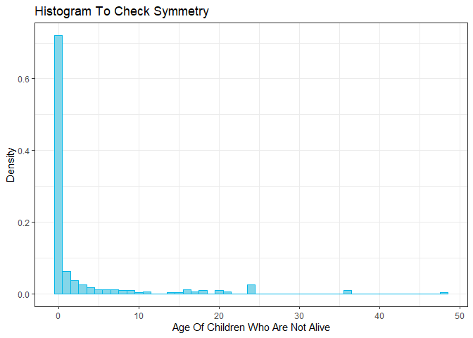

```r
q4_data[q4_data$B5==0,] %>%
  ggplot(aes(x = age_of_child)) +
  geom_histogram(aes(y = ..density..),
                 binwidth = 1,
                 fill = "#84d6e9",
                 color = "#00b6e8") +
  labs(title = "Histogram To Check Symmetry",
       x = "Age Of Children Who Are Not Alive",
       y = "Density") +
  theme_bw()
```

**5.** It is highly skewed. So, we consider the `median` as a suitable measure of central tendency.

```r
median(q4_data$age_of_child[q4_data$B5==0], na.rm = T)
## [1] 0
```

###### Describing Result:

Here, the median is 0 for a total of 357 cases. Sadly enough, that tells us the children in our observation died tended to live less than a month. They died in their neonatal period. Our data ranged from 0 months to 48 months, but the median lies at the minimum. It shows us how skewed our distribution is.

At least 50% of the children who died in our observation died in their neonatal period. From further analysis, we see out of 357 children who died, 257 died in their neonatal period. That is nearly 72%. So definitely median illustrates this issue better than mean. We also compared the infant death counts with neonatal deaths side-by-side in a bar chart. And this clearly shows how difficult the first one month is for a baby compared to the next eleven months.

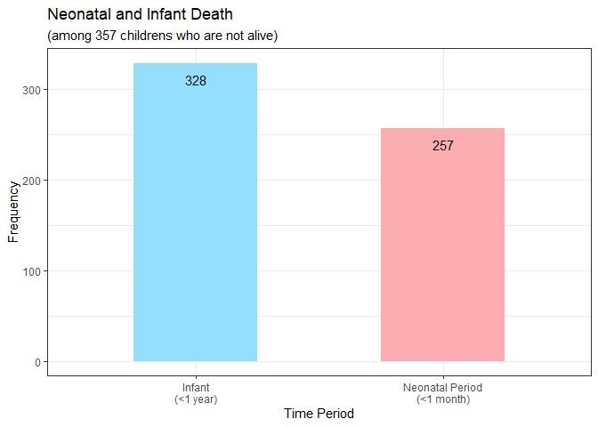

*Code for this graph is available [🔗 here](https://raw.githubusercontent.com/has9alv3/Data-Management/main/Graphs/Q4.%20Neonatal%20and%20Infant%20Death.R)*

## Resources

- All code are written in R.
- The full document is made using R Markdown.
- Code link for graphs in interpretation section are attached below the graph.
- All .R and .Rmd files are available on our [Github Repo](https://github.com/has9alv3/Data-Management).

END